# Baltimore Crime Map

**Introduction:** The goal of this project is to try to code up a simple system that reads and processes crime record data in the Baltimore Police Department, and visualizes crime location patterns depending on userspecified conditions.

**Download, unzip and read the shape file:**

```r
library(maps)
library(maptools)
url_zip <- 'https://dl.dropboxusercontent.com/s/chyvmlrkkk4jcgb/school_distr.zip'
if(!file.exists('school_distr.zip')) download.file(url_zip, 'school_distr.zip')
# download file as zip
unzip('school_distr.zip')   # unzip in the default folder
schdstr_shp <- readShapePoly('school.shp')  # read shape file
xlim <- schdstr_shp@bbox[1,]
ylim <- schdstr_shp@bbox[2,]
```

**Download and load the crime csv data:**

```r
url_csv <- 'https://dl.dropboxusercontent.com/s/4hg5ffdds9n2nx3/baltimore_crime.csv'
if(!file.exists('baltimore_crime.csv')) download.file(url_csv, 'baltimore_crime.csv')
df <- read.csv('baltimore_crime.csv', stringsAsFactors = F)
```

**Transform dates and time variables depending on what we need:**

```r
typeof(df$CrimeDate)
```

```
## [1] "character"
```

```r
df$year<-substr(df$CrimeDate,7,10)
df$month<-substr(df$CrimeDate,1,2)
df$day<-substr(df$CrimeDate,4,5)
df$CrimeDate <- as.Date(df$CrimeDate,"%m/%d/%Y")
df$year <- format(df$CrimeDate,"%Y")
df$month <- format(df$CrimeDate,"%m")
df$day <- format(df$CrimeDate,"%d")
df$time <- as.numeric(substr(df$CrimeTime,1,2))
```

**Transform coordinates data into numeric:** In the original data, there is a column called “Location1”. This variable indicate pairs of “(latitude,longitude)”. What I am doing below is to obtain two numeric variables of longitude and latitude.

```r
df$Location1 <- gsub("[()]", "", df$Location1)
getla <- function(x){
  grep("\\d+",unlist(strsplit(x,","))[1],value=T)
}   #just use the general idea and replace x with the specific one when applying the function

getlo <- function(x){
  grep("\\-\\d+",unlist(strsplit(x,","))[2],value=T)
}
df$latitude <- sapply(df$Location1,function(x) getla(x)) # work on each element
df$longitude <- sapply(df$Location1,function(x) getlo(x))
```

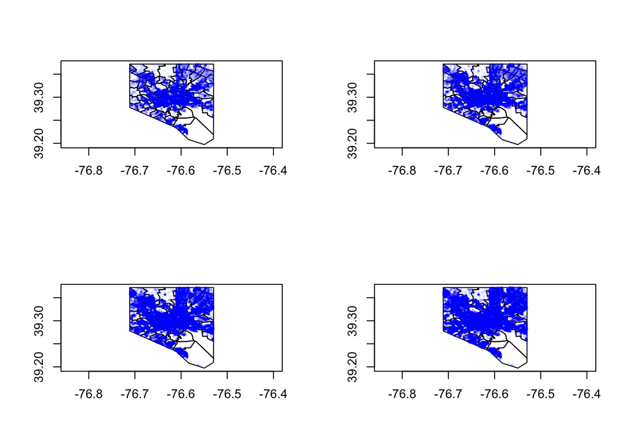

```r
par(mfrow = c(2, 2))
des <- grep("ASSAULT",df$Description,value=T)
for (t in c(0,6,12,18)){
    plot(schdstr_shp, axes = T)
    points(df$longitude[df$Description %in% des&df$time<t+6],df$latitude[df$Description %in% des&df$time<t+6], type = "p", col=rgb(0,0,1,0.05),pch=19,cex=0.3)
}
```